# Linear Regression Model

## Factors that affect a student’s score in a course

### ———- load data ———-

Data is from Wooldrigde(2015). Introductory econometrics: A modern approach

```r
load("econ.RDA")
```

Preview the data

```r
str(econ)
```

```
## 'data.frame':    814 obs. of  16 variables:
##  $ age     : int  23 23 21 22 22 22 22 22 22 21 ...
##  $ work    : num  15 0 25 30 25 0 20 20 28 22.5 ...
##  $ study   : num  10 22.5 12 40 15 30 25 15 7 25 ...
##  $ econhs  : Factor w/ 2 levels "0","1": 1 2 1 1 2 1 2 1 1 1 ...
##  $ colgpa  : num  3.49 2.1 3.09 2.68 3.75 ...
##  $ hsgpa   : num  3.35 3.22 3.31 3.98 3.89 ...
##  $ acteng  : int  24 23 21 31 28 25 15 28 28 18 ...
##  $ actmth  : int  26 20 24 28 31 30 19 30 28 19 ...
##  $ act     : int  27 24 21 31 32 28 18 32 30 17 ...
##  $ mathscr : Ord.factor w/ 10 levels "1"<"2"<"3"<"4"<..: 10 9 8 10 8 10 9 9 6 9 ...
##  $ male    : Factor w/ 2 levels "0","1": 2 2 2 1 2 2 1 2 1 1 ...
##  $ calculus: Factor w/ 2 levels "0","1": 2 1 2 2 2 2 2 2 1 2 ...
##  $ att     : Factor w/ 3 levels "0","1","2": 1 1 3 2 2 3 2 3 3 2 ...
##  $ fathcoll: Factor w/ 2 levels "0","1": 2 1 1 2 1 1 1 2 1 1 ...
##  $ mothcoll: Factor w/ 2 levels "0","1": 2 2 2 2 2 2 1 2 2 1 ...
##  $ score   : num  84.4 57.4 66.4 81.2 95.9 ...
```

```r
head(econ)
```

|  | age | work | study | econhs | colgpa | hsgpa | acteng | actmth | act | mathscr | male | calculus | att | fathcoll | mothcoll | score |
| --- | --- | --- | --- | --- | --- | --- | --- | --- | --- | --- | --- | --- | --- | --- | --- | --- |
| 1 | 23 | 15 | 10.0 | 0 | 3.4909 | 3.355 | 24 | 26 | 27 | 10 | 1 | 1 | 0 | 1 | 1 | 84.43 |
| 2 | 23 | 0 | 22.5 | 1 | 2.1000 | 3.219 | 23 | 20 | 24 | 9 | 1 | 0 | 0 | 0 | 1 | 57.38 |
| 3 | 21 | 25 | 12.0 | 0 | 3.0851 | 3.306 | 21 | 24 | 21 | 8 | 1 | 1 | 2 | 0 | 1 | 66.39 |
| 4 | 22 | 30 | 40.0 | 0 | 2.6805 | 3.977 | 31 | 28 | 31 | 10 | 0 | 1 | 1 | 1 | 1 | 81.15 |
| 5 | 22 | 25 | 15.0 | 1 | 3.7454 | 3.890 | 28 | 31 | 32 | 8 | 1 | 1 | 1 | 0 | 1 | 95.90 |
| 6 | 22 | 0 | 30.0 | 0 | 3.0555 | 3.500 | 25 | 30 | 28 | 10 | 1 | 1 | 2 | 0 | 1 | 83.61 |

Dependant variable is Score. For linear regression, linear means linear in parameters.

Suppose interested to know how a change in College GPA can change a student’s final score, can fit a simple linear regression:

```r
slm <- lm(score ~ colgpa, data = econ)
summary(slm)
```

```
##
## Call:
## lm(formula = score ~ colgpa, data = econ)
##
## Residuals:
##     Min      1Q  Median      3Q     Max
## -41.784  -6.399   0.564   7.553  32.183
##
## Coefficients:
##             Estimate Std. Error t value Pr(>|t|)
## (Intercept)  32.3463     2.0181   16.03   <2e-16 ***
## colgpa       14.3232     0.7051   20.31   <2e-16 ***
## ---
## Signif. codes:  0 '***' 0.001 '**' 0.01 '*' 0.05 '.' 0.1 ' ' 1
##
## Residual standard error: 10.84 on 812 degrees of freedom
## Multiple R-squared:  0.337,  Adjusted R-squared:  0.3361
## F-statistic: 412.6 on 1 and 812 DF,  p-value: < 2.2e-16
```

coefficients

```r
slm$coefficients
```

```
## (Intercept)      colgpa
##    32.34631    14.32317
```

```r
x <- econ$colgpa
y <- econ$score
beta1.hat <- cov(x,y) / var(x) # s_xx = (n-1) * var(x)
beta1.hat
```

```
## [1] 14.32317
```

```r
beta1.hat <- cor(x,y) * sd(y) / sd(x)
```

quantile

```r
alpha <- .05
n <- nrow(econ)
q <- qt(p = 1 - alpha/2, df = n-2)
```

residual standard error

```r
beta0.hat <- mean(y) - beta1.hat * mean(x)
y.hat <- beta0.hat + beta1.hat * x
res <- y - y.hat
sigma.hat <- sqrt(sum(res^2)/(n-2))
```

Std.Error, t value and p-value for beta1

```r
sxx <- (n-1) * var(x)
s1 <- sigma.hat / sqrt(sxx)
T1 <- beta1.hat / s1
pval <- 2 * pt(q = -abs(T1), df = n-2)
```

Std.Error, t value and p-value for beta0

```r
s0 <- sigma.hat * sqrt(1/n + mean(x)^2 / sxx)
T0 <- beta0.hat / s0
pval <- 2 * pt(q = -abs(T0), df = n-2)
```

Want to know if the effect of colgpa is significant.

$$\hat{B_1}/s_1|H_0 \sim t_{n-2}$$

3. if $T_{obs}$ is the particular value of the test statistic calculated for dataset $y_{obs}$, then

$$p = Pr(T> T_{obs}|H_0)$$

is the probability that a new, randomly selected dataset y will have a more extreme value of the rest statistic than $y_{obs}$

### ———- simple linear model: model checking ———-

first create a perfect linear model as a contrast

```r
x0 <- rnorm(n) # predictors
eps <- rnorm(n) # errors
y0 <- 1 + x0 + eps
plm <- lm(y0 ~ x0)
```

1. check the linear trend, i.e. E(y|x) = beta0 + beta1*x

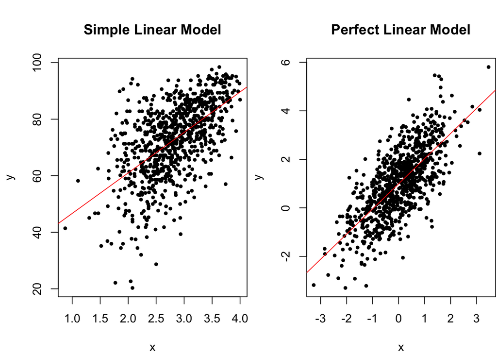

```r
par(mfrow = c(1,2), mar = c(4,4,4,0)+.1)
pt.cex <- .7
{plot(x, y, pch = 16, cex = pt.cex, xlab = "x", ylab = "y", main = "Simple Linear Model")
abline(slm, col = "red")}
{plot(x0, y0, pch = 16, cex = pt.cex, xlab = "x", ylab = "y", main = "Perfect Linear Model")
abline(plm, col = "red")}
```

2. check conditional homoscedasticity

Residuals vs Fitted Values

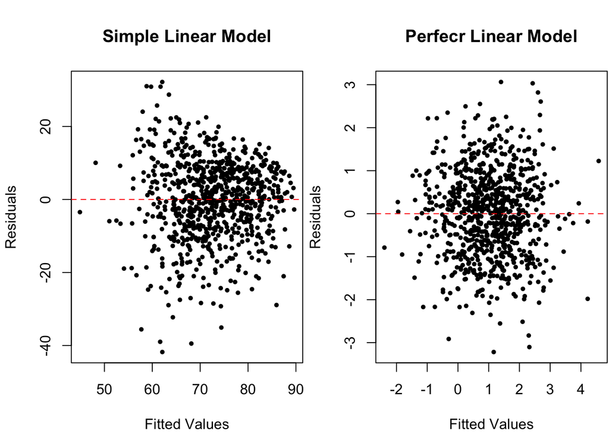

```r
par(mfrow = c(1,2), mar = c(4,4,4,0)+.1)
pt.cex <- .7
{plot(x = predict(slm), y = residuals(slm), # R way of calculating these
     pch = 16, cex = pt.cex,
     xlab = "Fitted Values", ylab = "Residuals", main = "Simple Linear Model")
abline(h = 0, col = "red", lty = 2)} # add horizontal line
{plot(x = predict(plm), y = residuals(plm), # R way of calculating these
     pch = 16, cex = pt.cex,
     xlab = "Fitted Values", ylab = "Residuals", main = "Perfecr Linear Model")
abline(h = 0, col = "red", lty = 2)} # add horizontal line
```

2. check normality

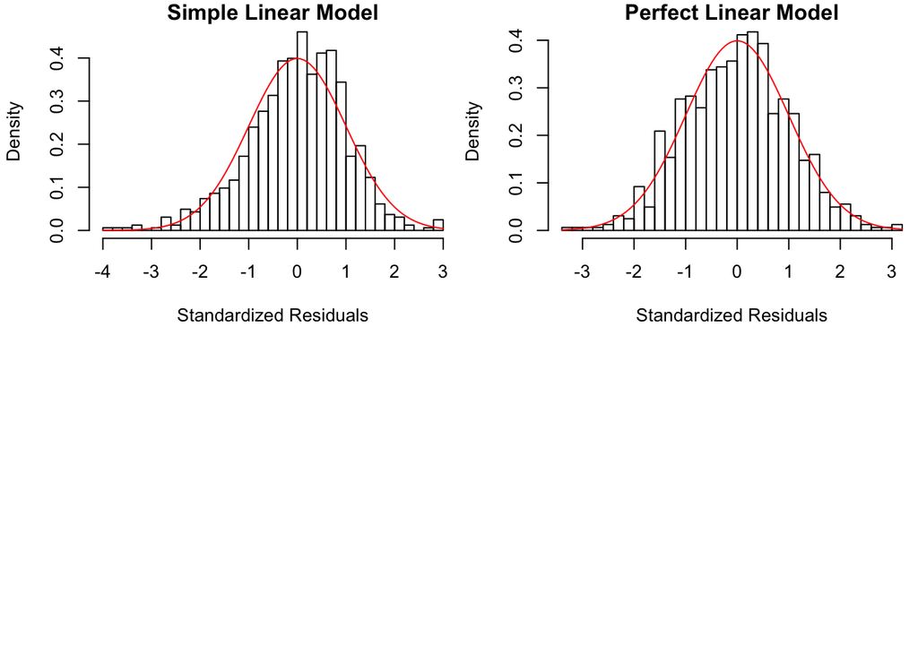

```r
zres <- residuals(slm)/sigma.hat
# histogram
par(mfrow = c(2,2), mar = c(4,4,1,0)+.1)
nbr <- 40 # may dramatically affect the histogram
{hist(zres,
     breaks = nbr, # number of bins
     freq = FALSE, # make area under hist = 1 (as opposed to counts)
     xlab = "Standardized Residuals", main = "Simple Linear Model")
# add a standard normal curve for reference
curve(dnorm, add = TRUE, col = "red")}

{hist(eps,
     breaks = nbr, # number of bins
     freq = FALSE, # make area under hist = 1 (as opposed to counts)
     xlab = "Standardized Residuals", main = "Perfect Linear Model")
# add a standard normal curve for reference
curve(dnorm, add = TRUE, col = "red")}
```

qq plots

shows that the simple linear model is a bit left skewed.

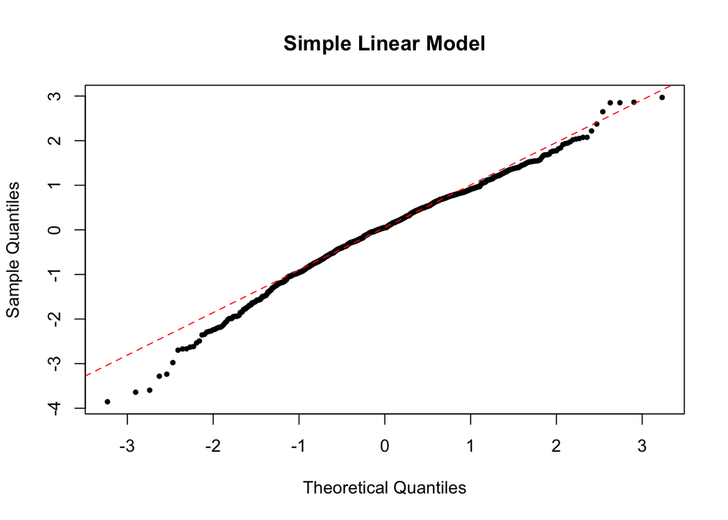

```r
{qqnorm(zres, main = "Simple Linear Model", pch = 16, cex = .7)
qqline(zres, col = "red", lty = 2)}
```

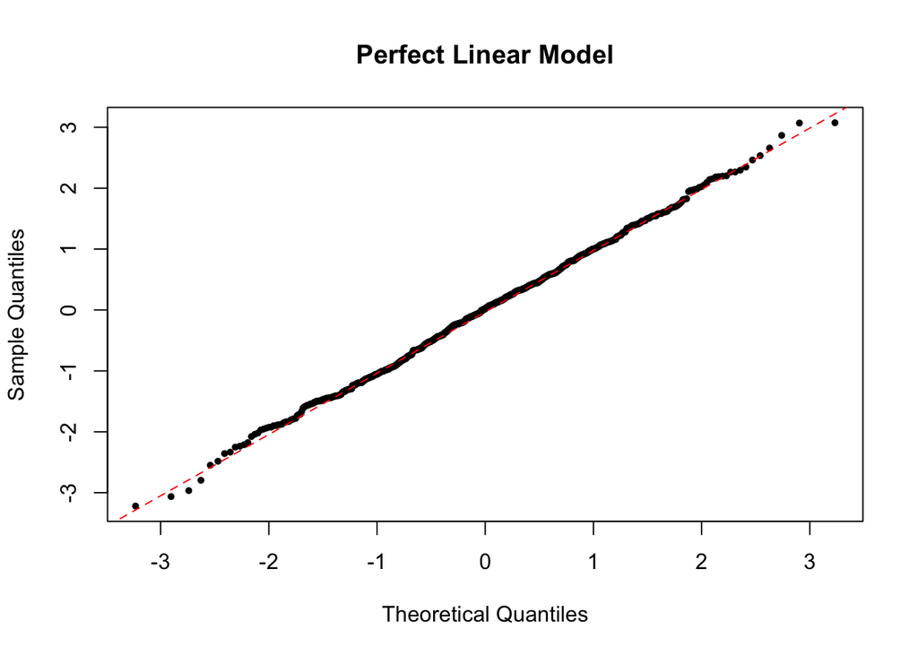

```r
{qqnorm(eps, main = "Perfect Linear Model", pch = 16, cex = .7)
qqline(eps, col = "red", lty = 2)}
```

### ———- simple linear regression vs two-sample t test ———-

When the independent variable is a binary vairable, the simple linear regression is equivalent to a two-sample t test.

e.g.: y = score, x = echonhs

Group1: econhs = 1, students who have taken econ in HS

Model: $y_i = B_0 + B_1x_i + e_i$

t statistic (with unknown $\sigma$) for testing $H_{0}: B_{1} = 0$ is equivalent to that of a two sample t test:

$$t = \frac{\bar{x_1} - \bar{x_2}}{s_1 \sqrt{1/n_1 + 1/n_2}} \sim t(n1+n2-2)$$

```r
model <- lm(score ~ econhs, data = econ)
# summary of linear model
summary(model)
```

```
##
## Call:
## lm(formula = score ~ econhs, data = econ)
##
## Residuals:
##     Min      1Q  Median      3Q     Max
## -52.645  -8.205   1.635   9.939  25.485
##
## Coefficients:
##             Estimate Std. Error t value Pr(>|t|)
## (Intercept)  72.9549     0.5846 124.799   <2e-16 ***
## econhs1      -0.9519     0.9694  -0.982    0.326
## ---
## Signif. codes:  0 '***' 0.001 '**' 0.01 '*' 0.05 '.' 0.1 ' ' 1
##
## Residual standard error: 13.3 on 812 degrees of freedom
## Multiple R-squared:  0.001186,   Adjusted R-squared:  -4.415e-05
## F-statistic: 0.9641 on 1 and 812 DF,  p-value: 0.3264
```

```r
# two-sample t test (not paired, sample sizes different)
t.test(score ~ econhs, var.equal = TRUE, data = econ)
```

```
##
##  Two Sample t-test
##
## data:  score by econhs
## t = 0.98189, df = 812, p-value = 0.3264
## alternative hypothesis: true difference in means is not equal to 0
## 95 percent confidence interval:
##  -0.9509953  2.8547115
## sample estimates:
## mean in group 0 mean in group 1
##        72.95486        72.00301
```

```r
# anova
summary(aov(score ~ econhs, data = econ))
```

```
##              Df Sum Sq Mean Sq F value Pr(>F)
## econhs        1    171   170.7   0.964  0.326
## Residuals   812 143738   177.0
```

```r
# replicate the above results
n <- nrow(econ)
res <- residuals(model)
sigma.hat <- sqrt(sum(res^2)/(n-2))
id <- (econ$econhs == 1)
mean1 <- mean(econ$score[id])
mean0 <- mean(econ$score[!id])
n1 <- sum(id)
n2 <- n - n1
tval <- (mean0 - mean1) / (sigma.hat * sqrt(1/n1 + 1/n2))
tval
```

```
## [1] 0.9818899
```

t-test review link:

https://blog.minitab.com/blog/adventures-in-statistics-2/understanding-t-tests-1-sample-2-sample-and-paired-t-tests

t-test are a type of hypothesis testing that allows one to compare means.

1. 1-sample t-test $t = \frac{\bar{x} - \mu_0}{s/\sqrt{n}}$, analogy is that t-value is signal-to-noise ratio. The numerator is the signal, which is taking the sample mean and subtract the null hypothesis value. The denominator is the noise, which is the standard error of the mean. This statistic indicates how accurately your sample estimates the mean of the population. A larger number indicates the sample estimate is less precise because it has more random error. Including noise factor to determine whether the signal is large enough to standout from it. Relatively large signals and low levels of noise produce larger t-values.
2. A paired t-test

Paired t-test is just 1-sample t-test.1-sample t-test compares one sample mean to a null hypothesis value. A paired t-test simply calculates the difference between paired observations (e.g., before and after) and then performs a 1-sample t-test on the differences.

3. Two-sample T-test

2-sample t-test takes sample data from two groups and boils it down to the t-value. Unlike the paired t-test, 2-sample t-test requires independent groups for each sample.

$$t = \frac{\bar{x_1} - \bar{x_2}}{s}$$

For 2-sample t-test the numerator is the signal, the difference between the two means. Default hypothesis is 2 groups are equal. Denominator is the noise.

### ———- multiple linear regression ———-

partialling out interpretation

```r
model1 <- lm(score ~ colgpa + hsgpa, data = econ)
model1$coefficients
```

```
## (Intercept)      colgpa       hsgpa
##   19.126435   12.666816    5.343784
```

```r
model2 <- lm(colgpa ~ hsgpa, data = econ)
rr <- model2$residuals
model3 <- lm(econ$score ~ rr)
model3$coefficients
```

```
## (Intercept)          rr
##    72.60873    12.66682
```

## Multiple Linear Regression

The problem with simple linear regression is that it is very difficult to draw ceteris paribus conclusions about how x affects y. The key assumption – that all other factors affecting y are uncorrelated with x – is often unrealistic.

The general Multiple Linear Regression Model with n samples and p variables can be written as

$$y_i = B_0 + B_1x_{i1} + ... + B_{p}x_{ip} + e_i$$

With $e_i \sim N(0, \sigma^2)$. Can also write the model in matrix notation

$y = XB + e$, $e \sim N(0, \sigma^2I)$

y is a nX1 vector, B is a px1 vector of params and X is an nXp matrix, called a model matrix.

By OLS or MLE, can show that

$\hat{B} = (X'X)^{-1}X'y$ where $\hat{B} \sim N(B, \sigma^2(X'X)^{-1})$

The fitted response vector is given by:

$\hat{y} \sim N(B, \sigma^2(X'X)^{-1})$

The residuals are given by

$e = y - \hat{y} = (I-H)y$

unbiased estimator of $\sigma^2$

$\sigma^2 = \frac{e'e}{n-p}$

E.G. if only hvae 2 covariates colgpa and hsgpa and the fitted model is written as:

$\hat{y_i} = \hat{B_0} + \hat{B_1}colgpa + \hat{B_2}hsgpa$

One way to express $\hat{B_1}$ is

$\hat{B_1} = \frac{\sum_{i=1}^{n}\hat{r_{i1}}y_i}{\sum_{i=1}^{n}\hat{r_{i1}}^2}$

The power of Multiple regression analysis is that it provides a ceteris paribus interpretation even though the data have not been collected in a ceteris paribus fashion. $\hat{B_1}$ means the effect of colgpa on score with hsgpa fixed.

### interaction effect

Interaction can be introduced between any type of covariate, continuous and continuous, continuous and discrete, discrete and discrete.

e.g. if wish to know whether the impact of colgpa on score would be different or not if a student has taken calculus before, need to introduct interaction term:

$y_i = B_0 + B_1colgpa_i + B2I(calculus_i = 1) +B_3(colgpa*I(calculus_i=1))+e_i$

B2 measures the difference in score between the two groups when colgpa = 0.

```r
# partialling out interpretation
model1 <- lm(score ~ colgpa + hsgpa, data = econ)
model1$coefficients
```

```
## (Intercept)      colgpa       hsgpa
##   19.126435   12.666816    5.343784
```

```r
model2 <- lm(colgpa ~ hsgpa, data = econ)
rr <- model2$residuals
model3 <- lm(econ$score ~ rr)
model3$coefficients
```

```
## (Intercept)          rr
##    72.60873    12.66682
```

```r
model4 <- lm(score ~ colgpa + calculus, data = econ)
# colgpa*calculus = colgpa + calculus + colgpa:calculus
model5 <- lm(score ~ colgpa*calculus, data = econ)
# substract the mean of colgpa
# this only changes the estimated coefficient of calculus and its std error
# now beta2 means the effect of calculus at the level colgpa = mean(colgpa)
econ_tmp <- econ
econ_tmp$colgpa <- econ$colgpa - mean(econ$colgpa)
model6 <- lm(score ~ colgpa*calculus, data = econ_tmp)
```

### ——– model selection ———

1. Minimize Residual Sum Square
2. Don’t overfit
3. Trade off between explanatory vs predictive power

Selections:

- Forward selection
- Backward selection
- Stepwise selection
- Lasso, minimize SSE with penalty term

```r
# bounds for model selection
M0 <- lm(score ~ 1, data = econ) # minimal model: intercept only
# maximal model: all main effects and all interaction effects except with career
Mfull <- lm(score ~ (. - acteng - actmth)^2, data = econ)
# forward (trace prints out information)
Mfwd <- step(object = M0, scope = list(lower = M0, upper = Mfull), direction = "forward", trace = FALSE)
# backward
Mbck <- step(object = Mfull, scope = list(lower = M0, upper = Mfull), direction = "backward", trace = FALSE)
# stepwise
Mstart <- lm(score ~ . - acteng - actmth, data = econ)
Mstep <- step(object = Mstart, scope = list(lower = M0, upper = Mfull), direction = "both", trace = FALSE)
# compare the three models
Mfwd$call
```

```
## lm(formula = score ~ colgpa + act + calculus + work + male +
##     hsgpa + colgpa:act + act:work + calculus:male + colgpa:male +
##     act:calculus, data = econ)
```

```r
Mbck$call
```

```
## lm(formula = score ~ age + work + study + econhs + colgpa + hsgpa +
##     act + mathscr + male + calculus + att + fathcoll + mothcoll +
##     age:study + age:econhs + age:hsgpa + age:act + age:calculus +
##     age:mothcoll + work:act + work:fathcoll + work:mothcoll +
##     study:act + econhs:hsgpa + econhs:male + econhs:calculus +
##     econhs:fathcoll + colgpa:act + colgpa:male + colgpa:att +
##     hsgpa:act + hsgpa:mothcoll + act:calculus + act:att + act:fathcoll +
##     mathscr:calculus + male:calculus + calculus:att + calculus:fathcoll +
##     fathcoll:mothcoll, data = econ)
```

```r
Mstep$call
```

```
## lm(formula = score ~ age + work + study + econhs + colgpa + hsgpa +
##     act + male + calculus + mothcoll + age:study + econhs:hsgpa +
##     study:act + age:calculus + hsgpa:mothcoll + econhs:male +
##     colgpa:male + male:calculus + work:act + act:calculus + hsgpa:act,
##     data = econ)
```

```r
# compare the AIC for three models
AIC(Mfwd)
```

```
## [1] 6066.812
```

```r
AIC(Mbck)
```

```
## [1] 6051.472
```

```r
AIC(Mstep)
```

```
## [1] 6049.366
```

```r
# Mstep gives the best model, we then manully select the variables
# # relabel att levels
econ2 <- econ
levels(econ2$att) <- c("0", "0", "1") # 1 is for excellent attendence
# # also delete some insignificant effects
model <- lm(formula = score ~ age + work + colgpa + hsgpa + acteng +
            act + calculus + acteng:act +
            work:act + age:calculus + colgpa:att +
            hsgpa:mothcoll + colgpa:male +
            acteng:att + acteng:mothcoll, data = econ2)
# --------- variable selection using lasso ---------
library(caret)
library(glmnet)
ctrl <- trainControl(method = "cv", number = 10)
tuneGrid <- expand.grid(.alpha = 1, .lambda = seq(.01, 1, length = 100))
glmnTuned <- train(score ~ ., data = econ, method = "glmnet",
                   tuneGrid = tuneGrid,
                   trControl = ctrl)
glmnTuned$bestTune
```

|  | alpha | lambda |
| --- | --- | --- |
| 33 | 1 | 0.33 |

```r
# we find the best lambda = 0.33
# get the coefficients of the best tuned model
coef(glmnTuned$finalModel, s = 0.33)
```

```
## 25 x 1 sparse Matrix of class "dgCMatrix"
##                      1
## (Intercept) 14.5987653
## age          .
## work        -0.1032683
## study        .
## econhs1      .
## colgpa      10.9288251
## hsgpa        2.2520238
## acteng       .
## actmth       0.4588251
## act          0.3143123
## mathscr.L    0.1058592
## mathscr.Q    .
## mathscr.C    .
## mathscr^4   -0.3098328
## mathscr^5    .
## mathscr^6    .
## mathscr^7    2.4472188
## mathscr^8    .
## mathscr^9    .
## male1        1.6096165
## calculus1    2.7753716
## att1         .
## att2         .
## fathcoll1    .
## mothcoll1    .
```

### Model Diagnostics

1. Scatterplot

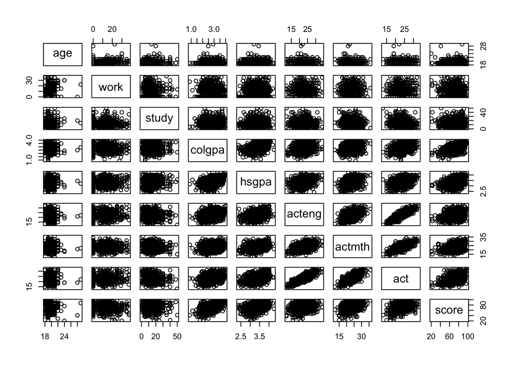

```r
pairs(~ age + work + study + colgpa + hsgpa + acteng + actmth + act + score, data = econ)
```

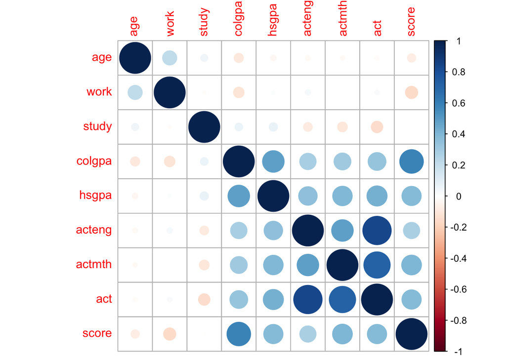

```r
library(corrplot)
tmp <- data.matrix(econ[ ,c(1:3,5:9,16)])
corrplot(cor(tmp), method = "circle")
```

2. residuals vs fitted values

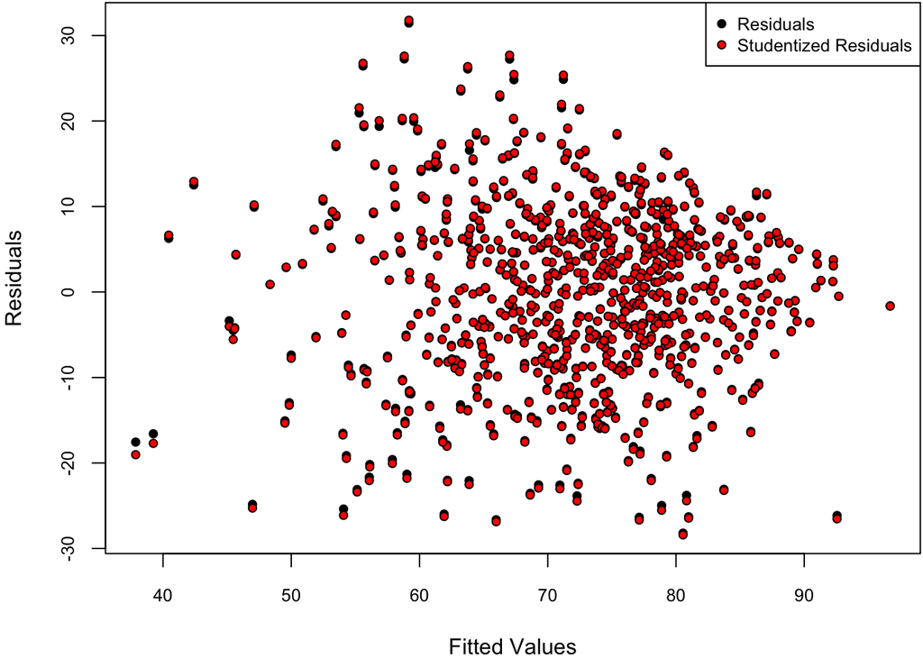

```r
model <- Mstep
res <- residuals(model)
X <- model.matrix(model)
H <- X %*% solve(t(X) %*% X) %*% t(X)
h <- diag(H)
res.stu <- res/sqrt(1-h)
cex <- .8 # controls the size of the points and labels
par(mar = c(4,4,.1,.1))
{plot(predict(model), res, pch = 21, bg = "black", cex = cex, cex.axis = cex,
     xlab = "Fitted Values", ylab = "Residuals")
points(predict(model), res.stu, pch = 21, bg = "red", cex = cex)
legend(x = "topright", c("Residuals", "Studentized Residuals"),
       pch = 21, pt.bg = c("black", "red"), pt.cex = cex, cex = cex)}
```

3. Normality

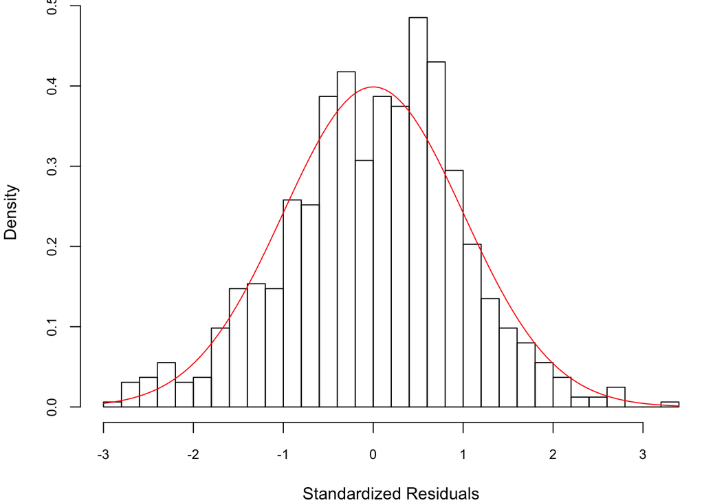

```r
# plot standardized residuals
sigma.hat <- sqrt(sum(resid(model)^2)/model$df)
cex <- .8
par(mar = c(4,4,.1,.1))
{hist(res/sigma.hat, breaks = 40, freq = FALSE, cex.axis = cex,
     xlab = "Standardized Residuals", main = "")
curve(dnorm(x), col = "red", add = TRUE)} # theoretical normal curve}
```

4. Colinearity

If two covariates are highly correlated, regression has trouble figuring out whether change in y is due to one covariate or the other. Thus estimates of B can change a lot from one random sample to another. This is known as variance inflation. Can detect Colinearity by checking VIF.

```r
# VIF: variance inflation factors, greater than 10 may be a concern
# the variance inflation factors are the diagonals of the correlation matrix
VIF <- diag(solve(cor(X[,-1])))
VIF
```

```
##             age            work           study         econhs1          colgpa
##        7.770210       46.525339      504.720169      102.459175        2.709420
##           hsgpa             act           male1       calculus1       mothcoll1
##       48.832698       96.426232       31.367398      485.743872      103.682678
##       age:study   econhs1:hsgpa       study:act   age:calculus1 hsgpa:mothcoll1
##      474.380538      100.084609       38.978467      432.142151      107.230801
##   econhs1:male1    colgpa:male1 male1:calculus1        work:act   act:calculus1
##        2.756511       30.368043        4.535092       48.216588       56.105448
##       hsgpa:act
##      204.524169
```

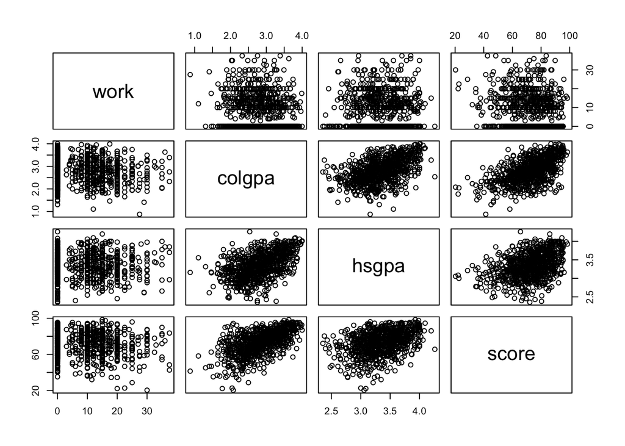

```r
# re-fit the model and then go back to diagnostics
# model <- lm(formula = score ~ work + study + econhs + colgpa + hsgpa +
#             act + calculus + mothcoll + econhs:hsgpa +
#             study:act  + hsgpa:mothcoll +
#             colgpa:male + male:calculus + work:act + act:calculus + hsgpa:act,
#             data = econ)
model <- lm(formula = score ~ work + colgpa + hsgpa +
              calculus + colgpa:male + male:calculus, data = econ)
pairs(~ work + colgpa + hsgpa + score, data = econ)
```

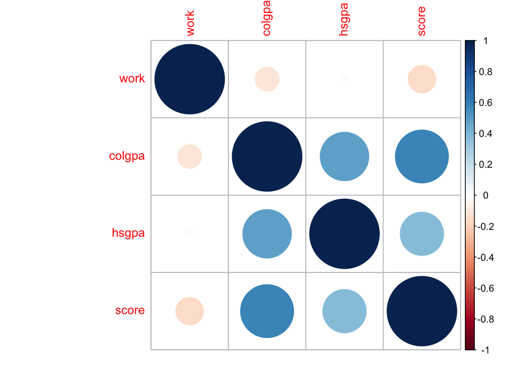

```r
corrplot(cor(econ[,c("work", "colgpa", "hsgpa", "score")]), method = "circle")
```